# 06.Example 1

## Given:

A very long rod $5 mm$ in diameter has one end maintained at $100 ^\circ C$. The surface of the rod is exposed to ambient air at $25 ^\circ C$ with a convection heat transfer coefficient of $100 \frac{W}{m^2K}$.

## Required:

(a) Determine the temperature distributions along rods constructed from pure copper, 2024 aluminum alloy, and type AISI 316 stainless steel. What are the corresponding heat losses from the rods?  
(b) Estimate how long the rods must be for the assumption of infinite length to yield an accurate estimate of the heat loss.

## Solution:

Start first by importing any needed libraries.

```python
import math
import matplotlib.pyplot as plt
import numpy as np
import pint # https://pint.readthedocs.io
```

The unit registry may then be defined. This is shown below.

```python
ureg = pint.UnitRegistry()
Q_ = ureg.Quantity
```

The given problem variables may now be defined with units.

```python
D = Q_(5, 'mm')
T_b = Q_(100, 'degC')
T_inf = Q_(25, 'degC')
h = Q_(100, 'W/(m**2*K)')
```

The material properties will be evaluated at the average temperature of $T_b$ and $T_\infty$. So  
$\bar{T}=\frac{T_b+T_\infty}{2}$

```python
Tbar = (T_b.to('K') + T_inf.to('K'))/2
Tbar.to('K')
```

335.65 kelvin

Going to table A.1 for copper, aluminum, and stainless steel at $\bar{T}$ shows that interpolation is needed. This is shown below.

```python
T_A = Q_(200, 'K')
T_B = Q_(400, 'K')
k_A = Q_(413, 'W/(m*K)')
k_B = Q_(393, 'W/(m*K)')
k_cu = ((Tbar - T_A)/(T_B - T_A))*(k_B - k_A) + k_A
round(k_cu, 2)
```

399.44 watt/(kelvin meter)

```python
T_A = Q_(200, 'K')
T_B = Q_(400, 'K')
k_A = Q_(163, 'W/(m*K)')
k_B = Q_(186, 'W/(m*K)')
k_al = ((Tbar - T_A)/(T_B - T_A))*(k_B - k_A) + k_A
round(k_al, 2)
```

178.6 watt/(kelvin meter)

```python
T_A = Q_(300, 'K')
T_B = Q_(400, 'K')
k_A = Q_(13.4, 'W/(m*K)')
k_B = Q_(15.2, 'W/(m*K)')
k_ss = ((Tbar - T_A)/(T_B - T_A))*(k_B - k_A) + k_A
round(k_ss, 2)
```

14.04 watt/(kelvin meter)

Going to the tip conditions table found in the notes shows that the temperature distribution function for an infinite long fin is  
$\theta = \theta_b e^{-mx}$  
Or this may be expressed in terms of temperature as  
$T = \left(T_b-T_\infty \right) e^{-mx}+T_\infty$  
where $m$ is  
$m=\sqrt{\frac{hP}{k A_c}}$  
For a round fin with a constant cross sectional area, the $P$ and $A_c$ terms may be expressed as  
$P=\pi D$  
$A_c=\frac{\pi}{4}D^2$  
The $m$ term then becomes  
$m=\sqrt{\frac{4h}{kD}}$  
For the different materials, this is

```python
m_cu = (4*h/(k_cu*D))**0.5
round(m_cu.to('1/m'), 2)
```

14.15 1/meter

```python
m_al = (4*h/(k_al*D))**0.5
round(m_al.to('1/m'), 2)
```

21.16 1/meter

```python
m_ss = (4*h/(k_ss*D))**0.5
round(m_ss.to('1/m'), 2)
```

75.48 1/meter

To plot the temperature distribution, a Python function may be used. This is shown below.

```python
def Tdist(x, m):
    return (T_b.to('K') - T_inf.to('K'))*math.e**(-m*x) + T_inf.to('K')
```

The $x$ values for the plot may now be created using a Numpy array ranging from $0mm$ to $350mm$. This is shown below.

```python
x = np.linspace(0, 350)*ureg.mm
```

The temperature values may now be found using the temperature distribution function `Tdist`. This is shown below.

```python
T_cu = Tdist(x, m_cu)
T_al = Tdist(x, m_al)
T_ss = Tdist(x, m_ss)
```

The plot may now be built. This is shown below.

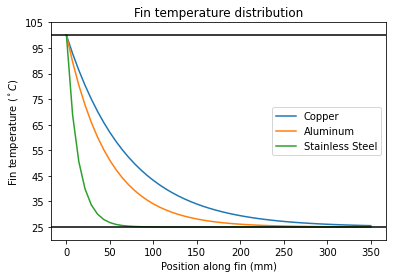

```python
fig, ax = plt.subplots(1, 1)

ax.plot(x.to('mm').magnitude, T_cu.to('degC').magnitude, label = 'Copper')
ax.plot(x.to('mm').magnitude, T_al.to('degC').magnitude, label = 'Aluminum')
ax.plot(x.to('mm').magnitude, T_ss.to('degC').magnitude, label = 'Stainless Steel')

ax.set_xlabel('Position along fin (mm)')
ax.set_ylabel('Fin temperature ($^\\circ C$)')
ax.set_title('Fin temperature distribution')

ax.axhline(y = T_b.to('degC').magnitude, color = 'k')
ax.axhline(y = T_inf.to('degC').magnitude, color = 'k')

ax.set_ylim([20, 105])
ax.set_yticks(range(25, 110, 10))

ax.legend()
plt.show()
```

The heat loss from the fin the is given by  
$q_f=\sqrt{hPkA_c}\theta_b=\sqrt{h\left(\pi D\right)k\left(\frac{\pi}{4} D^2\right)}\theta_b=\sqrt{\frac{\pi^2 h k D^3}{4}}\theta_b$  
For the different materials, this becomes

```python
q_cu = ((math.pi**2*h*k_cu*D**3)/4)**0.5*(T_b - T_inf)
round(q_cu.to('W'), 2)    # answer to second portion of part (a)
```

8.32 watt

```python
q_al = ((math.pi**2*h*k_al*D**3)/4)**0.5*(T_b - T_inf)
round(q_al.to('W'), 2)    # answer to second portion of part (a)
```

5.57 watt

```python
q_ss = ((math.pi**2*h*k_ss*D**3)/4)**0.5*(T_b - T_inf)
round(q_ss.to('W'), 2)    # answer to second portion of part (a)
```

1.56 watt

To find the required length of fin for it to be considered infinitely long, we must first realize that an infinitely long fin will have adiabatic condition at the tip. Referring to the tip conditions table, it shows that the heat loss from the fin for the adiabatic tip is  
$q_f=\sqrt{hPkA_c}\tanh m L$  
Comparing this to the heat loss from the fin for the infinitely long fin, it may be seen that the difference is the hyperbolic tangent function. Thus, for the two cases to be the same, the hyperbolic tangent function must be equal to 1. The hyperbolic tangent function is never 1, though. However, it gets infinitely close to 1. We may approximate this by saying the hyperbolic tangent function is $99$. That is  
$\tanh m L = 0.99$  
Taking the inverse of the hyperbolic tangent function of $0.99$ is shown below.

```python
math.atanh(0.99)
```

```
2.6466524123622457
```

```python
L_cu = math.atanh(0.99)/((4*h)/(k_cu*D))**0.5
round(L_cu.to('mm'), 1)    # answer to part (b)
```

187.0 millimeter

```python
L_al = math.atanh(0.99)/((4*h)/(k_al*D))**0.5
round(L_al.to('mm'), 1)    # answer to part (b)
```

125.1 millimeter

```python
L_ss = math.atanh(0.99)/((4*h)/(k_ss*D))**0.5
round(L_ss.to('mm'), 1)    # answer to part (b)
```

35.1 millimeter

Download Complete Python Script Here